# BBB - Logistic Regression

## Setup

Please complete this Rmarkdown document by answering the questions in `bbb-logistic.pdf` on Dropbox (week5/readings/). Create an Notebook / HTML file with all your results and comments and push both the Rmarkdown and HTML file to GitLab when you are done. All results MUST be reproducible (i.e., the TA and I must be able to recreate the HTML from the Rmarkdown file without changes or errors).

> Note: If you use Rstudio’s git tab to push your subimssion to GitLab you may see warnings or messages when pushing the HTML file because of its size. To avoid these messages you can also push your files to GitLab by using GitGadget’s “Sync” tab (i.e., Commit your changes and then Push).

```r
## loading the data. Note that data *must* be loaded from Dropbox/MGTA455-2019/data
bbb_wrk <- readr::read_rds(file.path(find_dropbox(), "MGTA455-2019/data/bbb.rds"))
result<- radiant.model::logistic(bbb_wrk,'buyer',c('gender', 'last', 'total', 'child', 'youth', 'cook', 'do_it', 'reference', 'art', 'geog'))
prediction_bbb  <- result%>%
  predict(pred_data = bbb_wrk)
summary(result)
```

```
Logistic regression (GLM)
Data                 : bbb_wrk
Response variable    : buyer
Level                : yes in buyer
Explanatory variables: gender, last, total, child, youth, cook, do_it, reference, art, geog
Null hyp.: there is no effect of x on buyer
Alt. hyp.: there is an effect of x on buyer

                OR coefficient std.error z.value p.value
 (Intercept)            -2.361     0.049 -47.891  < .001 ***
 gender|M    2.140       0.761     0.036  21.272  < .001 ***
 last        0.910      -0.095     0.003 -33.918  < .001 ***
 total       1.001       0.001     0.000   5.630  < .001 ***
 child       0.830      -0.186     0.017 -10.775  < .001 ***
 youth       0.893      -0.113     0.026  -4.327  < .001 ***
 cook        0.763      -0.270     0.017 -15.782  < .001 ***
 do_it       0.583      -0.539     0.027 -19.994  < .001 ***
 reference   1.265       0.235     0.027   8.837  < .001 ***
 art         3.176       1.156     0.022  52.185  < .001 ***
 geog        1.776       0.574     0.019  30.824  < .001 ***

Signif. codes:  0 '***' 0.001 '**' 0.01 '*' 0.05 '.' 0.1 ' ' 1

Pseudo R-squared: 0.205
Log-likelihood: -12061.106, AIC: 24144.211, BIC: 24241.229
Chi-squared: 6233.253 df(10), p.value < .001
Nr obs: 50,000
```

Odd ratio of art is 3.176 which is the strongest positive varible.Odd ration of do_it is 0.583 which is the strongest negative varible.Because 1/0.583<3.176, art is the most important variable.P value is all smaller than 0.001 so all the variable here is significant.

```r
library(dplyr)
prediction_bbb<- prediction_bbb %>%
  mutate(prob_dec = radiant.data::xtile(Prediction, 10,rev=TRUE)/10)%>%
  mutate(acctnum = as.character(10000+as.numeric(rownames(prediction_bbb))))%>%
  right_join(bbb_wrk[,c(1,19)],by = 'acctnum')%>%
  mutate(buyer = factor(x= buyer ,level= c('yes','no'),label= c(1,0)))
```

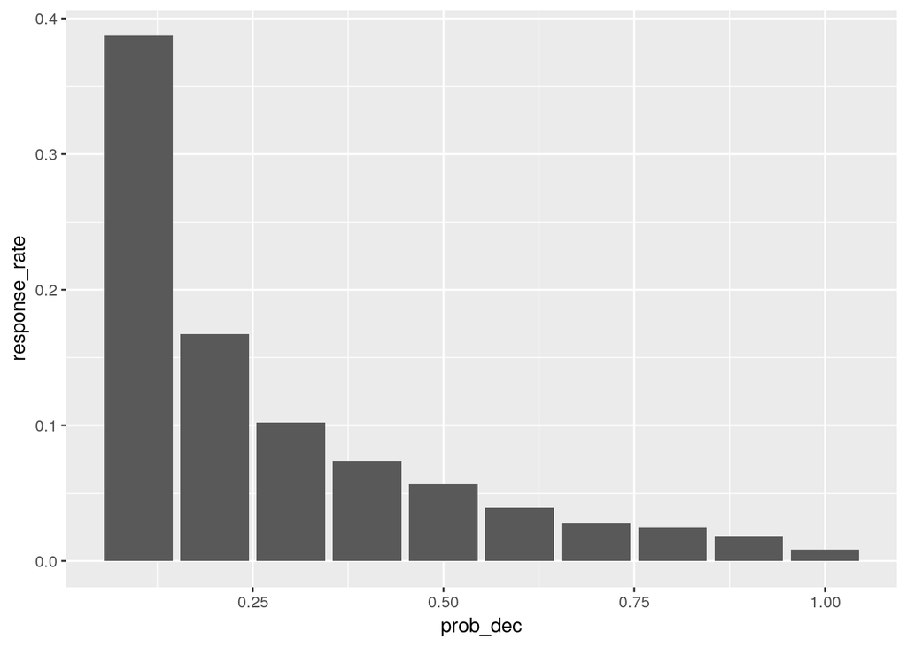

```r
plot <- prediction_bbb%>%
  group_by(prob_dec)%>%
  summarise(response_rate = mean(as.numeric(as.character(buyer))))%>%
  ggplot(aes(x=prob_dec,y=response_rate))+geom_bar(stat='identity')
plot
```

```r
#part2 quetion3
report1 <- prediction_bbb %>%
  group_by(prob_dec)%>%
  summarise(response_rate = mean(as.numeric(as.character(buyer))),number_of_customer = n(),number_of_buyer = sum(as.numeric(as.character(buyer))))
report1
```

```
# A tibble: 10 x 4
   prob_dec response_rate number_of_customer number_of_buyer
      <dbl>         <dbl>              <int>           <dbl>
 1      0.1        0.387                5000            1935
 2      0.2        0.167                5000             836
 3      0.3        0.102                5000             511
 4      0.4        0.0736               4999             368
 5      0.5        0.0568               5001             284
 6      0.6        0.0392               5000             196
 7      0.7        0.0278               4998             139
 8      0.8        0.0242               5002             121
 9      0.9        0.018                5000              90
10      1          0.0084               5000              42
```

```r
result2<- radiant.model::logistic(bbb_wrk,'buyer',c('child'))
summary(result2)
```

```
Logistic regression (GLM)
Data                 : bbb_wrk
Response variable    : buyer
Level                : yes in buyer
Explanatory variables: child
Null hyp.: there is no effect of child on buyer
Alt. hyp.: there is an effect of child on buyer

                OR coefficient std.error  z.value p.value
 (Intercept)            -2.374     0.020 -119.412  < .001 ***
 child       1.077       0.074     0.013    5.606  < .001 ***

Signif. codes:  0 '***' 0.001 '**' 0.01 '*' 0.05 '.' 0.1 ' ' 1

Pseudo R-squared: 0.001
Log-likelihood: -15162.545, AIC: 30329.089, BIC: 30346.729
Chi-squared: 30.375 df(1), p.value < .001
Nr obs: 50,000
```

When we only use child as explanatory variable or of child is 1.077. Compared to the raw model, or is 0.830.That means child change from a negetive variable to a lightly positive variable.

```r
report1 <- report1 %>%
  mutate(Lift = response_rate / (sum(number_of_buyer)/sum(number_of_customer)))%>%
  mutate(cumulative_response_rate = cumsum(number_of_buyer)/cumsum(number_of_customer))%>%
  mutate(Cum_Lift = cumulative_response_rate / (sum(number_of_buyer)/sum(number_of_customer)))
report1
```

```
# A tibble: 10 x 7
   prob_dec response_rate number_of_customer number_of_buyer   Lift cumulative_response_rate Cum_Lift
      <dbl>         <dbl>              <int>           <dbl>  <dbl>                    <dbl>    <dbl>
 1      0.1        0.387                5000            1935 4.28                     0.387      4.28
 2      0.2        0.167                5000             836 1.85                     0.277      3.06
 3      0.3        0.102                5000             511 1.13                     0.219      2.42
 4      0.4        0.0736               4999             368 0.814                    0.183      2.02
 5      0.5        0.0568               5001             284 0.628                    0.157      1.74
 6      0.6        0.0392               5000             196 0.433                    0.138      1.52
 7      0.7        0.0278               4998             139 0.308                    0.122      1.35
 8      0.8        0.0242               5002             121 0.267                    0.110      1.21
 9      0.9        0.018                5000              90 0.199                    0.0996     1.10
10      1          0.0084               5000              42 0.0929                   0.0904     1
```

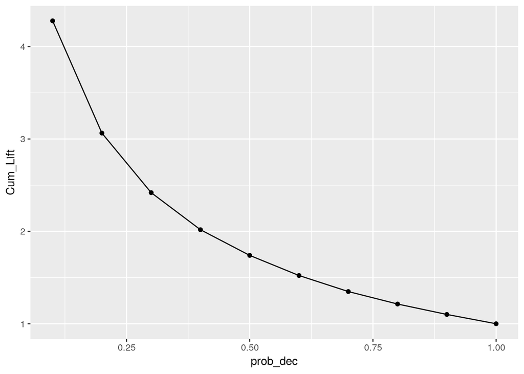

```r
plot3 <- report1%>%
  ggplot(aes(x=prob_dec,y=Cum_Lift))+geom_point()+geom_line()
plot3
```

```r
report2 <- report1 %>%
  mutate(cum_buyer = cumsum(number_of_buyer))%>%
  mutate(Gains = number_of_buyer /sum(number_of_buyer))%>%
  mutate(Cum_gains = cum_buyer/sum(number_of_buyer))
report2
```

```
# A tibble: 10 x 10
   prob_dec response_rate number_of_customer number_of_buyer   Lift cumulative_response_rate Cum_Lift cum_buyer   Gains Cum_gains
      <dbl>         <dbl>              <int>           <dbl>  <dbl>                    <dbl>    <dbl>     <dbl>   <dbl>     <dbl>
 1      0.1        0.387                5000            1935 4.28                     0.387      4.28      1935 0.428       0.428
 2      0.2        0.167                5000             836 1.85                     0.277      3.06      2771 0.185       0.613
 3      0.3        0.102                5000             511 1.13                     0.219      2.42      3282 0.113       0.726
 4      0.4        0.0736               4999             368 0.814                    0.183      2.02      3650 0.0814      0.807
 5      0.5        0.0568               5001             284 0.628                    0.157      1.74      3934 0.0628      0.870
 6      0.6        0.0392               5000             196 0.433                    0.138      1.52      4130 0.0433      0.913
 7      0.7        0.0278               4998             139 0.308                    0.122      1.35      4269 0.0307      0.944
 8      0.8        0.0242               5002             121 0.267                    0.110      1.21      4390 0.0268      0.971
 9      0.9        0.018                5000              90 0.199                    0.0996     1.10      4480 0.0199      0.991
10      1          0.0084               5000              42 0.0929                   0.0904     1         4522 0.00929     1
```

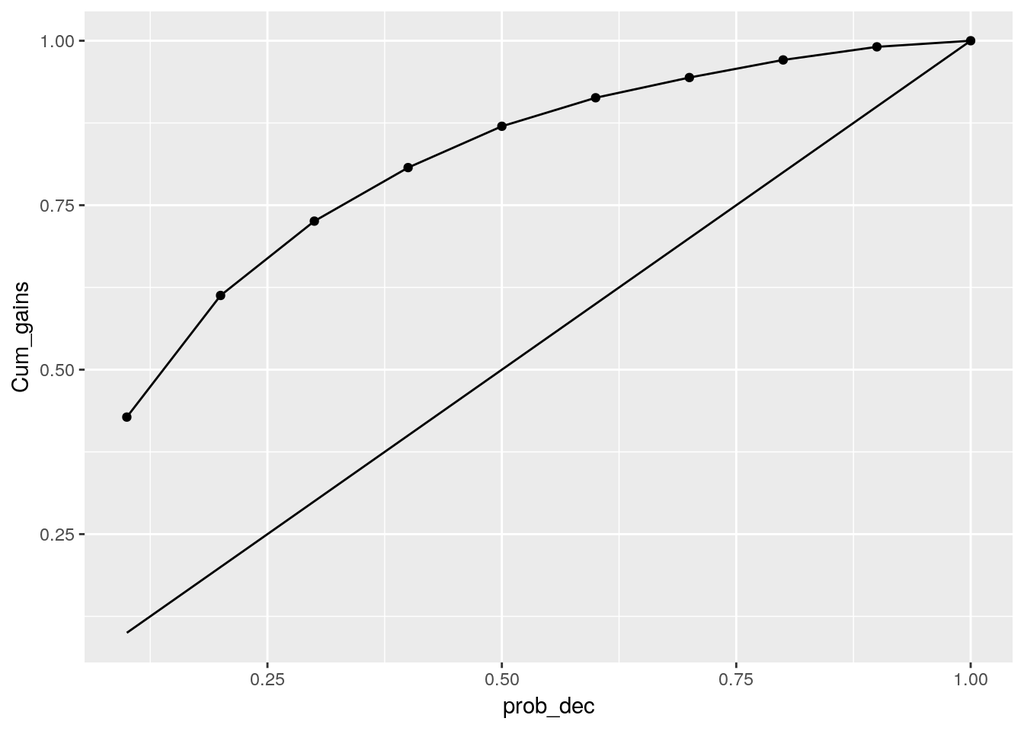

```r
reference<- data.frame(x= 1:10/10,y=1:10/10)
plot4 <- report2%>%
  ggplot(aes(x=prob_dec,y=Cum_gains))+geom_point()+geom_line()+geom_line(aes(x=reference$x,y=reference$y))
plot4
```

```r
#confusion matrix
threshold <- 0.5
confusion_matrix <- prediction_bbb %>%
  mutate(Pred.buyer = as.numeric(Prediction > threshold)) %>%
  count(buyer,Pred.buyer)
confusion_matrix
```

```
# A tibble: 4 x 3
  buyer Pred.buyer     n
  <fct>      <dbl> <int>
1 1              0  3838
2 1              1   684
3 0              0 45126
4 0              1   352
```

```r
acc <- (confusion_matrix[2,3]+confusion_matrix[3,3])/sum(confusion_matrix$n)
cat('Model Accuracy=', as.numeric(unname(acc)))
```

```
Model Accuracy= 0.9162
```

```r
#Part5
break_even_response_rate = 0.5/(18-9-3)
prediction_bbb <- prediction_bbb %>%
  mutate(mailto_logit = Prediction > break_even_response_rate)
#question3
question3<- prediction_bbb %>%
  filter(mailto_logit ==TRUE)
expected_customer<- nrow(question3)/nrow(prediction_bbb)*500000
expected_buyer <-sum(as.numeric(as.character(question3$buyer)))/nrow(prediction_bbb)*500000
expected_response_rate <-expected_buyer/expected_customer
expected_customer
```

```
[1] 155600
```

```r
expected_buyer
```

```
[1] 33230
```

```r
expected_response_rate
```

```
[1] 0.2135604
```

when mailto_logit is TRUE,expected customers are 155600 and expected buyer is 33230.Response rate is 0.21356. Question4 ,expected profit is 33230*(18-9-3)-155600*0.5=121580 ROME is 121580/155600*0.5=1.5627

```r
prediction_witherror  <- result%>%
  predict(pred_data = bbb_wrk,conf_lev = 0.9, se = TRUE)
bbb <- store(bbb_wrk, prediction_witherror, name = c("purch_prob", "purch_prob_lb", "purch_prob_ub"))%>%
  mutate(buyer = factor(x= buyer ,level= c('yes','no'),label= c(1,0)))

prediction_witherror <- bbb %>%
  mutate(mailto_logit_lb =  purch_prob_lb> break_even_response_rate)%>%
  mutate(mailto_logit_ub = purch_prob_ub > break_even_response_rate)
#question3
question3_1<- prediction_witherror %>%
  filter(mailto_logit_lb ==TRUE)
expected_customer_lb<- nrow(question3_1)/nrow(prediction_witherror)*500000
expected_buyer_lb <-sum(as.numeric(as.character(question3_1$buyer)))/nrow(prediction_witherror)*500000
expected_response_rate_lb <-expected_buyer_lb/expected_customer_lb
cat('expected_customer_lb=',expected_customer_lb)
```

```
expected_customer_lb= 144430
```

```r
cat('expected_buyer_lb=', expected_buyer_lb)
```

```
expected_buyer_lb= 32340
```

```r
cat('expected_response_rate_lb=', expected_response_rate_lb)
```

```
expected_response_rate_lb= 0.2239147
```

```r
expected_profit_lb <- expected_buyer_lb*6-expected_customer_lb*0.5
ROME_lb <-expected_profit_lb/(expected_customer_lb*0.5)
cat('expected_profit_lb=', expected_profit_lb)
```

```
expected_profit_lb= 121825
```

```r
cat('ROME_LB=', ROME_lb)
```

```
ROME_LB= 1.686976
```

```r
question3_1<- prediction_witherror %>%
  filter(mailto_logit_ub ==TRUE)
expected_customer_ub<- nrow(question3_1)/nrow(prediction_witherror)*500000
expected_buyer_ub <-sum(as.numeric(as.character(question3_1$buyer)))/nrow(prediction_witherror)*500000
expected_response_rate_ub <-expected_buyer_ub/expected_customer_ub
cat('expected_customer_ub=',expected_customer_ub)
```

```
expected_customer_ub= 166950
```

```r
cat('expected_buyer_ub=', expected_buyer_ub)
```

```
expected_buyer_ub= 34180
```

```r
cat('expected_response_rate_ub=', expected_response_rate_ub)
```

```
expected_response_rate_ub= 0.204732
```

```r
expected_profit_ub <- expected_buyer_ub*6-expected_customer_ub*0.5
ROME_ub <-expected_profit_ub/(expected_customer_ub*0.5)
cat('expected_profit_ub=', expected_profit_ub)
```

```
expected_profit_ub= 121605
```

```r
cat('ROME_ub=', ROME_ub)
```

```
ROME_ub= 1.456783
```

ROME for lb is 1.686976 while ROME for ub is 1.456783 and ROME for normal is 1.5627. Which means that using low boundary is better.